# MAHINDRA SENTIMENT ANALYSIS

RITWIKA BHATTACHARJEE

06/09/2020

```r
library(dplyr)
library(tidyr)
```

```r
library(ggplot2)
CarSales <- read.csv("C:/Users/hp/Desktop/FALL-2020-21/Mahindra Project/Datasets/CarSales.csv", header=TRUE)
```

```r
head(CarSales)
```

```
##   Price.Category  OEM     Vehicle  Car.Category Cost  FY18 FY19
## 1           5-10  FCA  Avvenntura   compact SUV 9.00    NA   NA
## 2           5-10  FCA       Linea         Sedan 9.99   115   94
## 3           5-10  FCA       Punto         hatch 9.98    NA   NA
## 4           5-10  FCA Urban Cross     Crossover 9.85    NA   NA
## 5           5-10 Ford      Aspire Compact Sedan 8.34 16721 8718
## 6           5-10 Ford        Figo         Hatch 6.95  4130 8372
```

## **POSITIVE SENTIMENT ANALYSIS**

### **CARS IN PRICE RANGE 5-10**

```r
cars0to5 = CarSales %>%
  filter(Price.Category == '5-10')
#remove NA values

cars0to5 = cars0to5[complete.cases(cars0to5),]
```

#### Analysis by Manufacturer or OEM

```r
#Average sales of each manufacturer
cars0to5 %>%
  group_by(OEM) %>%
  summarise(avg_sales_2018 = mean(FY18), avg_sales_2019 = mean(FY19), total_avg_sales = (mean(FY18)+mean(FY19))/2) %>%
  dplyr::select(OEM, avg_sales_2018, avg_sales_2019, total_avg_sales) %>%
  arrange(desc(total_avg_sales))
```

```
## # A tibble: 11 x 4
##    OEM           avg_sales_2018 avg_sales_2019 total_avg_sales
##    <fct>                  <dbl>          <dbl>           <dbl>
##  1 Maruti Suzuki        148084.        120269          134176.
##  2 Hyundai               68314          76056.          72185.
##  3 Honda                 40930.         32391.          36660.
##  4 Tata                  40778.         31212           35995.
##  5 Mahindra              27212.         18213           22713.
##  6 Toyota                11949.         11802           11876.
##  7 Ford                  13165.          8928.          11046.
##  8 Volkswagen            11727.         10270.          10998.
##  9 Renault                4021          11216.           7619.
## 10 Nissan                 2015.          2160.           2088.
## 11 FCA                     115             94             104.
```

### **Observation:** It is observed that top 5 manufacturers corresponding to maximum sales in both years is Maruti Suzuki, Hyundai, Honda, Tata, Mahindra

#### Analysis by car manufacturer and car category

```r
#Average sales of each manufacturer and car category
cars0to5 %>%
  group_by(OEM, Car.Category) %>%
  summarise(avg_sales_2018 = mean(FY18), avg_sales_2019 = mean(FY19), total_avg_sales = (mean(FY18)+mean(FY19))/2) %>%
  dplyr::select(OEM, Car.Category, avg_sales_2018, avg_sales_2019, total_avg_sales) %>%
  arrange(desc(total_avg_sales))
```

```
## # A tibble: 36 x 5
## # Groups:   OEM [11]
##    OEM           Car.Category   avg_sales_2018 avg_sales_2019 total_avg_sales
##    <fct>         <fct>                   <dbl>          <dbl>           <dbl>
##  1 Maruti Suzuki Compact sedanÿ         264612        198904          231758
##  2 Maruti Suzuki Super Mini             223630        191901          207766.
##  3 Maruti Suzuki Hatch                  181128        169914.         175521.
##  4 Hyundai       Supermini              141104        123201          132152.
##  5 Maruti Suzuki Hatback                100957         70930           85944.
##  6 Hyundai       Hatch                   79495         83711           81603
##  7 Mahindra      SUV                     85464         69656           77560
##  8 Honda         Compact Sedan           67584         67715           67650.
##  9 Tata          SUV                     52519         49312           50916.
## 10 Hyundai       " compact SUV"              0         70443           35222.
## # … with 26 more rows
```

#### To analyse the sentiment of customers we have to find the prominent features in these car categories which primary attracted the customers

```r
CarFeatures <- read.csv("C:/Users/hp/Desktop/FALL-2020-21/Mahindra Project/Datasets/CarFeatures.csv", header=TRUE)
```

```r
CarFeatures = CarFeatures %>%
  filter(Price.Band..Lakh == "fiveten")
dim(CarFeatures)
```

```
## [1]  85 704
```

#### Displaying the list of features in each of these cars

```r
x = CarFeatures %>%
  filter(OEM == "Maruti Suzuki", Car.Category == "Compact sedanÿ") %>%
  dplyr::select(-Price.Band..Lakh, -OEM, -MODEL,-Car.Category, -LATEST.LAUNCH.1EAR.20..., -VARIANT, -COST.Ex.Showroom.)

x = x[ , colSums(is.na(x)) == 0]

features_list = colnames(x)
```

```r
x = CarFeatures %>%
  filter(OEM == "Maruti Suzuki", Car.Category == "Super Mini") %>%
  dplyr::select(-Price.Band..Lakh, -OEM, -MODEL,-Car.Category, -LATEST.LAUNCH.1EAR.20..., -VARIANT, -COST.Ex.Showroom.)

x = x[1,]
x = x[ , colSums(is.na(x)) == 0]

features_list = append(features_list, colnames(x))
```

```r
x = CarFeatures %>%
  filter(OEM == "Maruti Suzuki", Car.Category == "Hatch") %>%
  dplyr::select(-Price.Band..Lakh, -OEM, -MODEL,-Car.Category, -LATEST.LAUNCH.1EAR.20..., -VARIANT, -COST.Ex.Showroom.)

x = x[ , colSums(is.na(x)) == 0]

features_list = append(features_list, colnames(x))
```

```r
x = CarFeatures %>%
  filter(OEM == "Hyundai", Car.Category == "Supermini") %>%
  dplyr::select(-Price.Band..Lakh, -OEM, -MODEL,-Car.Category, -LATEST.LAUNCH.1EAR.20..., -VARIANT, -COST.Ex.Showroom.)

x = x[ , colSums(is.na(x)) == 0]

features_list = append(features_list, colnames(x))
```

```r
x = CarFeatures %>%
  filter(OEM == "Maruti Suzuki", Car.Category == "Hatback") %>%
  dplyr::select(-Price.Band..Lakh, -OEM, -MODEL,-Car.Category, -LATEST.LAUNCH.1EAR.20..., -VARIANT, -COST.Ex.Showroom.)

x = x[ , colSums(is.na(x)) == 0]

features_list = append(features_list, colnames(x))
```

```r
x = CarFeatures %>%
  filter(OEM == "Hyundai", Car.Category == "Hatch") %>%
  dplyr::select(-Price.Band..Lakh, -OEM, -MODEL,-Car.Category, -LATEST.LAUNCH.1EAR.20..., -VARIANT, -COST.Ex.Showroom.)

x = x[ , colSums(is.na(x)) == 0]

features_list = append(features_list, colnames(x))
```

```r
x = CarFeatures %>%
  filter(OEM == "Mahindra", Car.Category == "SUV") %>%
  dplyr::select(-Price.Band..Lakh, -OEM, -MODEL,-Car.Category, -LATEST.LAUNCH.1EAR.20..., -VARIANT, -COST.Ex.Showroom.)

x = x[ , colSums(is.na(x)) == 0]

features_list = append(features_list, colnames(x))
```

```r
x = CarFeatures %>%
  filter(OEM == "Honda", Car.Category == "Compact Sedan") %>%
  dplyr::select(-Price.Band..Lakh, -OEM, -MODEL,-Car.Category, -LATEST.LAUNCH.1EAR.20..., -VARIANT, -COST.Ex.Showroom.)

x = x[ , colSums(is.na(x)) == 0]

features_list = append(features_list, colnames(x))
```

```r
x = CarFeatures %>%
  filter(OEM == "Tata", Car.Category == "SUV") %>%
  dplyr::select(-Price.Band..Lakh, -OEM, -MODEL,-Car.Category, -LATEST.LAUNCH.1EAR.20..., -VARIANT, -COST.Ex.Showroom.)

x = x[ , colSums(is.na(x)) == 0]

features_list = append(features_list, colnames(x))
```

```r
x = CarFeatures %>%
  filter(OEM == "Hyundai", Car.Category == " compact SUV") %>%
  dplyr::select(-Price.Band..Lakh, -OEM, -MODEL,-Car.Category, -LATEST.LAUNCH.1EAR.20..., -VARIANT, -COST.Ex.Showroom.)

x = x[ , colSums(is.na(x)) == 0]

features_list = append(features_list, colnames(x))
```

```r
#finding frequencies of each features in the top sold cars
freqdata = as.data.frame(table(features_list))
freqdata = freqdata %>%
  arrange(desc(Freq))
head(freqdata,30)
```

```
##                      features_list Freq
## 1                 Adjustable.Seats   10
## 2                  Air.Conditioner   10
## 3         Anti.Lock.Braking.S1stem   10
## 4                    Driver.Airbag   10
## 5       Electronic.Multi.Tripmeter   10
## 6               Engine.Immobilizer   10
## 7                Fabric.Upholster1   10
## 8               Front.Impact.Beams   10
## 9                Glove.Compartment   10
## 10                          Heater   10
## 11                   No.of.Airbags   10
## 12 Passenger.Side.Rear.View.Mirror   10
## 13                 Rear.Seat.Belts   10
## 14               Seat.Belt.Warning   10
```

[output cut: 16 more lines]

### **Observation** According to customers positive sentiment analysis these are the top 30 desirable features in cars of price range 5 to 10 lacs

#### Further we can also group the above features into types of features to understand which category of features is most valued by customers

```r
freqdata = freqdata %>%
  mutate(features_list = gsub('\\.',"",features_list))

FeatureDesc <- read.csv("C:/Users/hp/Desktop/FALL-2020-21/Mahindra Project/Datasets/FeatureDesc.csv")

FeatureDesc = FeatureDesc %>%
  mutate(Feature = gsub("[[:punct:]]", "", Feature)) %>%
  mutate(Feature = gsub(" ","",Feature))
```

```r
FeatureDesc$Feature.Category = as.character(FeatureDesc$Feature.Category)
library(stringr)
FeatureDesc$shortcat <- substr(word(FeatureDesc$Feature.Category, 1),1,8)

catlist=c()
for (i in seq(1,dim(freqdata)[1])){
  catlist = append(catlist, FeatureDesc$shortcat[FeatureDesc$Feature==as.character(freqdata$features_list[i])])
}
table(catlist)
```

```
## catlist
##  COMFORT ENTERTAI EXTERIOR INTERIOR   SAFETY
##       39       10       30       11       34
```

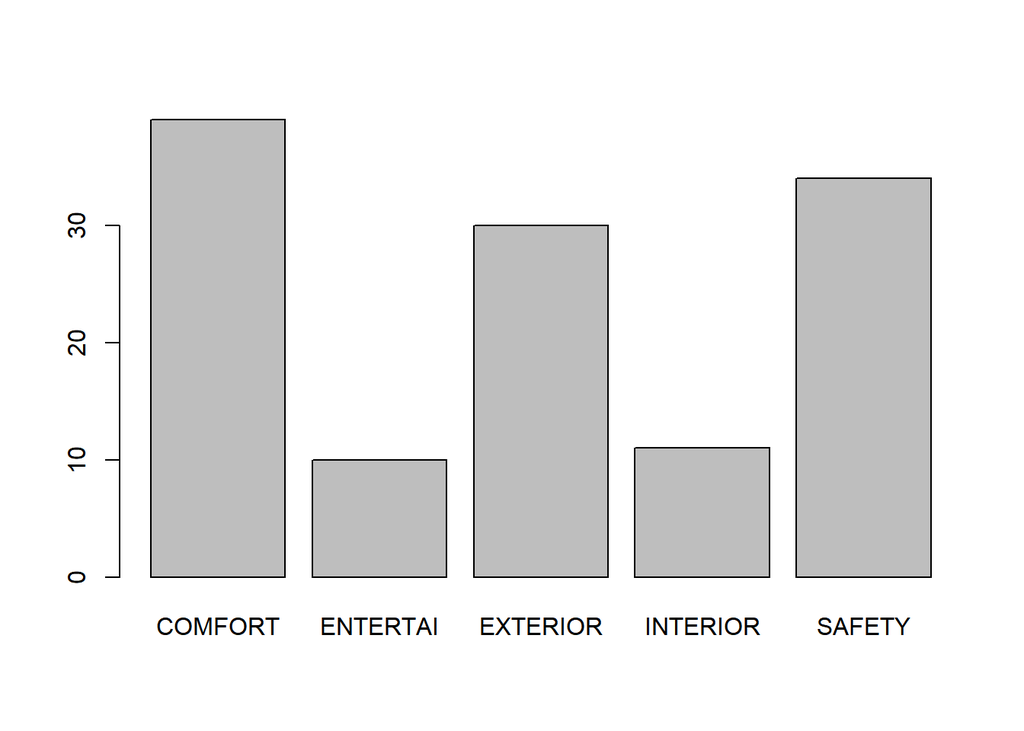

```r
barplot(table(catlist))
```

### **Observation: It can be observed from the above analysis that customers of cars in price range 5 to 10 lacs prefer Comfort, safety and exterior car features over entertainment and interior features**